# Regression Analysis of the 2016 Election

In this notebook, we assemble a county-level dataset of 2016 Presidential election results, voter registration counts, and various demographic, economic, and other county characteristics, and then fit a least-squares (linear) regression model to estimate the effects of various factors on the percentage of the vote won by Donald Trump in each county.

## The Model

An ordinary least-squares (OLS) regression of several explanatory variables on Trump’s percentage of the two-party vote provides us with a basic understanding of the partial relationships. The selected variables were chosen through trial-and-error, in pursuit of the goal of maximizing the explanatory power of the regression (maximum R-squared) while including only significant variables. For definitions of the variables, see https://github.com/Data4Democracy/election-transparency/blob/master/r-packages/uselections/README.md.

```r
ddf <- df %>%
  select(-MfgEmpChange1980_2015, -MfgEmpChange1990_2015, -BlindDisabledSSI) %>%
  na.omit()
result <- lm(rDRPct ~ Turnout+ThirdPartyVoteShare+LFPR+
               MedianHouseholdIncome+MedianHousingCosts+Age55Plus+Male+
               White+Hispanic+EdHS+EdCollege+Married+Uninsured+NonCitizen+
               SSIPerCapita+TexasBorderCounty+TotalReligiousPct+
               EvangelicalPct+MormonPct+UnemploymentRate+SimpsonDiversityIndex,
             data=ddf)
summary(result)
```

```
Call:
lm(formula = rDRPct ~ Turnout + ThirdPartyVoteShare + LFPR +
    MedianHouseholdIncome + MedianHousingCosts + Age55Plus +
    Male + White + Hispanic + EdHS + EdCollege + Married + Uninsured +
    NonCitizen + SSIPerCapita + TexasBorderCounty + TotalReligiousPct +
    EvangelicalPct + MormonPct + UnemploymentRate + SimpsonDiversityIndex,
    data = ddf)

Residuals:
      Min        1Q    Median        3Q       Max
-0.250267 -0.040603  0.001264  0.040346  0.311270

Coefficients:
                        Estimate Std. Error t value Pr(>|t|)
(Intercept)           -6.866e-02  4.751e-02  -1.445 0.148522
Turnout               -3.108e-02  3.431e-03  -9.057  < 2e-16 ***
ThirdPartyVoteShare   -1.231e+00  6.514e-02 -18.894  < 2e-16 ***
LFPR                  -1.811e-01  2.718e-02  -6.664 3.15e-11 ***
MedianHouseholdIncome  3.863e-06  2.649e-07  14.585  < 2e-16 ***
MedianHousingCosts    -2.348e-04  1.139e-05 -20.610  < 2e-16 ***
Age55Plus             -2.191e-01  3.596e-02  -6.093 1.24e-09 ***
Male                   3.936e-01  6.172e-02   6.377 2.07e-10 ***
White                  5.880e-01  1.892e-02  31.074  < 2e-16 ***
Hispanic              -9.680e-02  1.591e-02  -6.084 1.32e-09 ***
EdHS                  -1.819e-01  3.496e-02  -5.202 2.10e-07 ***
EdCollege             -8.339e-01  4.581e-02 -18.203  < 2e-16 ***
Married                7.522e-01  4.485e-02  16.771  < 2e-16 ***
Uninsured              3.884e-01  3.337e-02  11.639  < 2e-16 ***
NonCitizen            -2.189e-01  5.961e-02  -3.672 0.000245 ***
SSIPerCapita          -8.137e-04  2.137e-04  -3.807 0.000144 ***
TexasBorderCounty     -2.657e-01  1.564e-02 -16.994  < 2e-16 ***
TotalReligiousPct      6.466e-02  7.590e-03   8.520  < 2e-16 ***
EvangelicalPct         1.100e-01  7.132e-03  15.422  < 2e-16 ***
MormonPct              2.659e-01  1.392e-02  19.092  < 2e-16 ***
UnemploymentRate      -6.541e-01  1.019e-01  -6.418 1.59e-10 ***
SimpsonDiversityIndex  1.716e-01  1.776e-02   9.659  < 2e-16 ***
---
Signif. codes:  0 ‘***’ 0.001 ‘**’ 0.01 ‘*’ 0.05 ‘.’ 0.1 ‘ ’ 1

Residual standard error: 0.0665 on 3088 degrees of freedom
Multiple R-squared:  0.8308,    Adjusted R-squared:  0.8297
F-statistic: 722.2 on 21 and 3088 DF,  p-value: < 2.2e-16
```

This model achieves a fairly good goodness-of-fit (R-squared). Many of the explanatory variables have a sign consistent with the results of exit polls reported in the aftermath of the election. For example, the percentages of white, married, and religious residents in a county is positively, strongly and significantly correlated with Trump’s percentage of the vote. Conversely, the percentages of Hispanic and college-educated population are negatively correlated with Trump’s vote share.

## Residual Analysis

It is also interesting to examine the residuals from the regression above.

```r
ddf$rDRPct_fitted <- fitted(result)
ddf <- ddf %>%
  mutate(rDRPct_residual=rDRPct-rDRPct_fitted, predictedTrumpWin=rDRPct_fitted > .5) %>%
  arrange(rDRPct_residual)
```

The residual analysis allows us to consider the counties that deviate the most from the predicted Trump vote share, given each county’s characteristics.

The quartile values provided in the regression results indicate that the residuals are symmetrical about the expected mean of zero; a histogram confirms this:

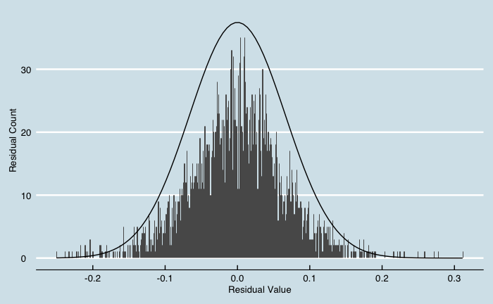

```r
nBins <- 500
scaleFac <- nrow(ddf) / nBins
ggplot(data=ddf) +
  geom_histogram(aes(x=rDRPct_residual), bins=nBins) +
  theme_economist() + labs(x='Residual Value', y='Residual Count') +
  stat_function(fun=function(x, mean, sd) {scaleFac*dnorm(x, mean, sd)},
                args=list(mean=mean(ddf$rDRPct_residual),
                          sd=sd(ddf$rDRPct_residual)))
```

Nevertheless, it is interesting to see if there is any geographic or other pattern to the residuals, as that may suggest other explanatory variables that we might include in the model to improve the fit. For a broad view, here is a county choropleth of the continental US that displays (using the familiar red-blue shading) the over (red) and under (blue) performance of Trump’s actual vote share versus what the model predicts:

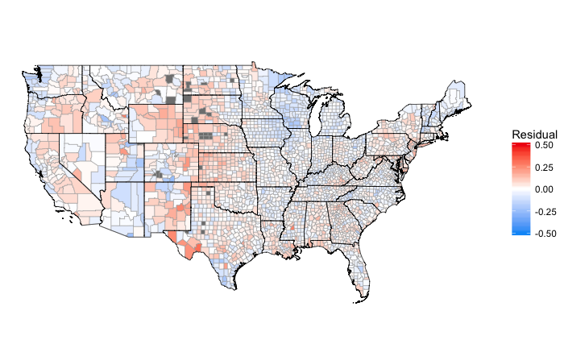

```r
data(state.regions)
conus <- setdiff(state.regions$region, c('alaska','hawaii'))
county_choropleth(ddf %>%
                    mutate(region=as.double(County), value=rDRPct_residual),
                  num_colors=1, state_zoom=conus) +
  scale_fill_gradient2(low="#0099F7", high="#F11712", midpoint=0,
                       limits=c(-0.5, 0.5)) + labs(fill='Residual')
```

Just eyeballing this choropleth, for the vast majority of the counties, the model fits fairly well (this is confirmed by the residual quartiles, which indicate that the predicted values for half the counties are within 4 points of the actual Trump vote share–represented by the faintest blue and red hues on the map). The extremes of Trump over-performance are in the Great Plains, eastern Colorado and New Mexico, the Big Bend region of Texas, eastern Oregon, and the Central Valley of California. Clinton over-performed in Cascadia, the western half of the Four Corners region, extreme southern Texas, and the upper Mississippi Valley.

These are the ten counties where Trump most under-performed what the model would predict (actual % of two-party vote was lower than model-predicted):

```r
head(ddf %>% select(County=CountyName,
                    State=StateAbbr,
                    `Actual Trump Win %`=rDRPct,
                    `Predicted Trump Win %`=rDRPct_fitted,
                    Deviation=rDRPct_residual), n=10)
```

| County | State | Actual Trump Win % | Predicted Trump Win % | Deviation |
| --- | --- | --- | --- | --- |
| Costilla | CO | 0.3432574 | 0.5935243 | -0.2502668 |
| Haines | AK | 0.4009936 | 0.6392243 | -0.2382307 |
| Santa Cruz | AZ | 0.2500160 | 0.4833266 | -0.2333105 |
| Manassas Park | VA | 0.3510229 | 0.5791883 | -0.2281654 |
| Iowa | WI | 0.4189754 | 0.6414129 | -0.2224375 |
| Blaine | ID | 0.3423534 | 0.5644626 | -0.2221092 |
| Deer Lodge | MT | 0.4613975 | 0.6813808 | -0.2199832 |
| Vernon | WI | 0.5241235 | 0.7418407 | -0.2177173 |
| Jim Hogg | TX | 0.2082324 | 0.4250717 | -0.2168392 |
| LaGrange | IN | 0.7715541 | 0.9825495 | -0.2109954 |

And the ten counties where Trump most over-performed what the model would predict:

```r
tail(ddf %>% select(County=CountyName,
                    State=StateAbbr,
                    `Actual Trump Win %`=rDRPct,
                    `Predicted Trump Win %`=rDRPct_fitted,
                    Deviation=rDRPct_residual), n=10)
```

| County | State | Actual Trump Win % | Predicted Trump Win % | Deviation |
| --- | --- | --- | --- | --- |
| Utah | UT | 0.7817817 | 0.5661210 | 0.2156607 |
| Lincoln | CO | 0.8222512 | 0.6003504 | 0.2219008 |
| Union | NM | 0.7916667 | 0.5672123 | 0.2244543 |
| Jeff Davis | TX | 0.6222023 | 0.3973044 | 0.2248979 |
| Brewster | TX | 0.5258228 | 0.2947457 | 0.2310771 |
| Hudspeth | TX | 0.6082225 | 0.3582215 | 0.2500010 |
| De Baca | NM | 0.7626076 | 0.5032898 | 0.2593178 |
| Rankin | MS | 0.9709805 | 0.6984388 | 0.2725417 |
| Madison | ID | 0.8815815 | 0.6032118 | 0.2783697 |
| Terrell | TX | 0.6728972 | 0.3616269 | 0.3112703 |

Overall, the model correctly predicts the winner in 2928 out of 3110 counties, which is pretty good. However, when we aggregate the predicted county vote totals at the state level, the model gets 5 states wrong:

| State | Predicted Winner | Actual Winner | Predicted Trump Vote % | Actual Trump Vote % |
| --- | --- | --- | --- | --- |
| ME | Trump | Clinton | 54.50 | 48.57 |
| MN | Trump | Clinton | 52.41 | 49.17 |
| NH | Trump | Clinton | 53.45 | 49.80 |
| NV | Trump | Clinton | 51.37 | 48.71 |
| WA | Trump | Clinton | 50.60 | 41.21 |

An area of potential further research here is to look at refining the model–including, potentially, with non-linear approaches–to improve its predictive power.